[figure not shown]

[figure not shown]

# Pandas Group By operations on real-world data

### Any groupby operation involves one of the following operations on the original object. They are :

```
            -Splitting the Object

            -Applying a function

            -Combining the results
```

### In many situations, we split the data into sets and we apply some functionality on each subset. In the apply functionality, we can perform the following operations −

```
            Aggregation − computing a summary statistic

            Transformation − perform some group-specific operation

            Filtration − discarding the data with some condition
```

Let us now create a DataFrame object and perform all the operations on it −

```python
#import the pandas library
import pandas as pd

ipl_data = {'Team': ['Riders', 'Riders', 'Devils', 'Devils', 'Kings',
   'kings', 'Kings', 'Kings', 'Riders', 'Royals', 'Royals', 'Riders'],
   'Rank': [1, 2, 2, 3, 3,4 ,1 ,1,2 , 4,1,2],
   'Year': [2014,2015,2014,2015,2014,2015,2016,2017,2016,2014,2015,2017],
   'Points':[876,789,863,673,741,812,756,788,694,701,804,690]}
df = pd.DataFrame(ipl_data,index=[2,3,4,5,6,7,8,9,10,11,12,13])

df
```

[output not shown]

```python
 df.head()
```

[output not shown]

```python
df.dtypes
```

[output not shown]

# 1- splitting

### Pandas object can be split into any of their objects. There are multiple ways to split an object like −

```
        obj.groupby('key')
        obj.groupby(['key1','key2'])
        obj.groupby(key,axis=1)
```

Let us now see how the grouping objects can be applied to the DataFrame object

```python
df.groupby('Team')
```

[output not shown]

```python
list(df.groupby('Team'))
```

```
[('Devils',
       Team  Rank  Year  Points
  4  Devils     2  2014     863
  5  Devils     3  2015     673),
 ('Kings',
      Team  Rank  Year  Points
  6  Kings     3  2014     741
  8  Kings     1  2016     756
  9  Kings     1  2017     788),
 ('Riders',
        Team  Rank  Year  Points
  2   Riders     1  2014     876
  3   Riders     2  2015     789
  10  Riders     2  2016     694
  13  Riders     2  2017     690),
 ('Royals',
        Team  Rank  Year  Points
  11  Royals     4  2014     701
  12  Royals     1  2015     804),
 ('kings',
      Team  Rank  Year  Points
  7  kings     4  2015     812)]
```

### .groups : dict(group name , group labels)

```python
df.groupby('Team',).groups
```

```
{'Devils': Int64Index([4, 5], dtype='int64'),
 'Kings': Int64Index([6, 8, 9], dtype='int64'),
 'Riders': Int64Index([2, 3, 10, 13], dtype='int64'),
 'Royals': Int64Index([11, 12], dtype='int64'),
 'kings': Int64Index([7], dtype='int64')}
```

### .indices : dict(group name , group index)

```python
df.groupby('Team').indices
```

```
{'Devils': array([2, 3], dtype=int64),
 'Kings': array([4, 6, 7], dtype=int64),
 'Riders': array([ 0,  1,  8, 11], dtype=int64),
 'Royals': array([ 9, 10], dtype=int64),
 'kings': array([5], dtype=int64)}
```

### Group by with multiple columns −

```python
df.groupby(['Team','Year']).groups
```

```
{('Devils', 2014): Int64Index([4], dtype='int64'),
 ('Devils', 2015): Int64Index([5], dtype='int64'),
 ('Kings', 2014): Int64Index([6], dtype='int64'),
 ('Kings', 2016): Int64Index([8], dtype='int64'),
 ('Kings', 2017): Int64Index([9], dtype='int64'),
 ('Riders', 2014): Int64Index([2], dtype='int64'),
 ('Riders', 2015): Int64Index([3], dtype='int64'),
 ('Riders', 2016): Int64Index([10], dtype='int64'),
 ('Riders', 2017): Int64Index([13], dtype='int64'),
 ('Royals', 2014): Int64Index([11], dtype='int64'),
 ('Royals', 2015): Int64Index([12], dtype='int64'),
 ('kings', 2015): Int64Index([7], dtype='int64')}
```

```python
grouped=df.groupby(['Team','Year'])
for column_names,data in grouped:
    print(f"columns={column_names} \n{data}")
```

```
columns=('Devils', 2014)
     Team  Rank  Year  Points
4  Devils     2  2014     863
columns=('Devils', 2015)
     Team  Rank  Year  Points
5  Devils     3  2015     673
columns=('Kings', 2014)
    Team  Rank  Year  Points
6  Kings     3  2014     741
columns=('Kings', 2016)
    Team  Rank  Year  Points
8  Kings     1  2016     756
columns=('Kings', 2017)
    Team  Rank  Year  Points
9  Kings     1  2017     788
columns=('Riders', 2014)
     Team  Rank  Year  Points
2  Riders     1  2014     876
columns=('Riders', 2015)
     Team  Rank  Year  Points
3  Riders     2  2015     789
columns=('Riders', 2016)
      Team  Rank  Year  Points
10  Riders     2  2016     694
columns=('Riders', 2017)
      Team  Rank  Year  Points
13  Riders     2  2017     690
columns=('Royals', 2014)
      Team  Rank  Year  Points
11  Royals     4  2014     701
columns=('Royals', 2015)
      Team  Rank  Year  Points
12  Royals     1  2015     804
columns=('kings', 2015)
    Team  Rank  Year  Points
7  kings     4  2015     812
```

### #1

```python
data_grouped=df.groupby(['Year'])
```

```python
for name,group in data_grouped:
    print(f"{name}\n{group}")
```

```
2014
      Team  Rank  Year  Points
2   Riders     1  2014     876
4   Devils     2  2014     863
6    Kings     3  2014     741
11  Royals     4  2014     701
2015
      Team  Rank  Year  Points
3   Riders     2  2015     789
5   Devils     3  2015     673
7    kings     4  2015     812
12  Royals     1  2015     804
2016
      Team  Rank  Year  Points
8    Kings     1  2016     756
10  Riders     2  2016     694
2017
      Team  Rank  Year  Points
9    Kings     1  2017     788
13  Riders     2  2017     690
```

### #2

```python
teams_inf=df.groupby('Team')
```

```python
for team_name,team_inf in teams_inf:
    print(f"team name ={team_name}\n{team_inf}\n")
```

```
team name =Devils
     Team  Rank  Year  Points
4  Devils     2  2014     863
5  Devils     3  2015     673

team name =Kings
    Team  Rank  Year  Points
6  Kings     3  2014     741
8  Kings     1  2016     756
9  Kings     1  2017     788

team name =Riders
      Team  Rank  Year  Points
2   Riders     1  2014     876
3   Riders     2  2015     789
10  Riders     2  2016     694
13  Riders     2  2017     690

team name =Royals
      Team  Rank  Year  Points
11  Royals     4  2014     701
12  Royals     1  2015     804

team name =kings
    Team  Rank  Year  Points
7  kings     4  2015     812
```

### Select a Group

Using the get_group() method, we can select a single group.

```python
teams_inf.get_group("Devils")
```

|  | Team | Rank | Year | Points |
| --- | --- | --- | --- | --- |
| 4 | Devils | 2 | 2014 | 863 |
| 5 | Devils | 3 | 2015 | 673 |

## select certain column after grouping data

```python
list(df.groupby('Team')["Points"])
```

```
[('Devils',
  4    863
  5    673
  Name: Points, dtype: int64),
 ('Kings',
  6    741
  8    756
  9    788
  Name: Points, dtype: int64),
 ('Riders',
  2     876
  3     789
  10    694
  13    690
  Name: Points, dtype: int64),
 ('Royals',
  11    701
  12    804
  Name: Points, dtype: int64),
 ('kings',
  7    812
  Name: Points, dtype: int64)]
```

```python
list(df.groupby('Team').Points)
```

```
[('Devils',
  4    863
  5    673
  Name: Points, dtype: int64),
 ('Kings',
  6    741
  8    756
  9    788
  Name: Points, dtype: int64),
 ('Riders',
  2     876
  3     789
  10    694
  13    690
  Name: Points, dtype: int64),
 ('Royals',
  11    701
  12    804
  Name: Points, dtype: int64),
 ('kings',
  7    812
  Name: Points, dtype: int64)]
```

# 2- Applying a function

# 3- Combining the results

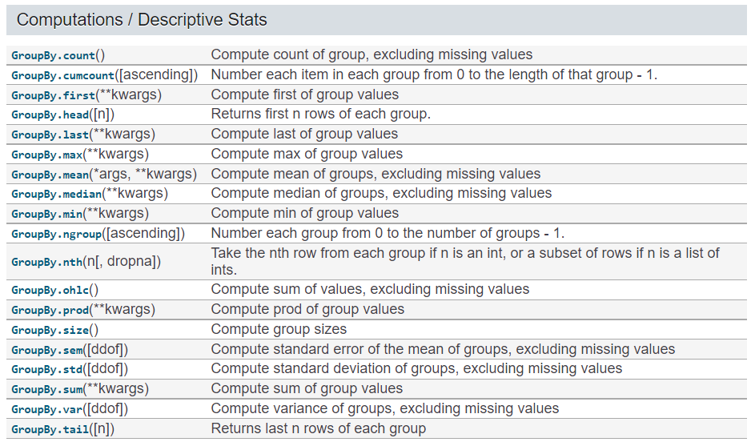

```python
df.groupby('Team').mean()
```

| Team | Rank | Year | Points |
| --- | --- | --- | --- |
| Devils | 2.500000 | 2014.500000 | 768.000000 |
| Kings | 1.666667 | 2015.666667 | 761.666667 |
| Riders | 1.750000 | 2015.500000 | 762.250000 |
| Royals | 2.500000 | 2014.500000 | 752.500000 |
| kings | 4.000000 | 2015.000000 | 812.000000 |

```python
df.groupby('Team').sum()
```

| Team | Rank | Year | Points |
| --- | --- | --- | --- |
| Devils | 5 | 4029 | 1536 |
| Kings | 5 | 6047 | 2285 |
| Riders | 7 | 8062 | 3049 |
| Royals | 5 | 4029 | 1505 |
| kings | 4 | 2015 | 812 |

```python
df.groupby('Team').size()
```

```
Team
Devils    2
Kings     3
Riders    4
Royals    2
kings     1
dtype: int64
```

```python
df.groupby('Team').std()
```

| Team | Rank | Year | Points |
| --- | --- | --- | --- |
| Devils | 0.707107 | 0.707107 | 134.350288 |
| Kings | 1.154701 | 1.527525 | 24.006943 |
| Riders | 0.500000 | 1.290994 | 88.567771 |
| Royals | 2.121320 | 0.707107 | 72.831998 |
| kings | NaN | NaN | NaN |

```python
df.groupby('Team').max()
```

| Team | Rank | Year | Points |
| --- | --- | --- | --- |
| Devils | 3 | 2015 | 863 |
| Kings | 3 | 2017 | 788 |
| Riders | 2 | 2017 | 876 |
| Royals | 4 | 2015 | 804 |
| kings | 4 | 2015 | 812 |

```python
df.groupby('Team')["Points"].max()
```

```
Team
Devils    863
Kings     788
Riders    876
Royals    804
kings     812
Name: Points, dtype: int64
```

```python
df.groupby('Team').Points.max()
```

```
Team
Devils    863
Kings     788
Riders    876
Royals    804
kings     812
Name: Points, dtype: int64
```

```python
df.groupby('Team').Points.get_group("Devils").max()
```

```
863
```

```python
list(df.groupby('Team')["Points"])
```

```
[('Devils',
  4    863
  5    673
  Name: Points, dtype: int64),
 ('Kings',
  6    741
  8    756
  9    788
  Name: Points, dtype: int64),
 ('Riders',
  2     876
  3     789
  10    694
  13    690
  Name: Points, dtype: int64),
 ('Royals',
  11    701
  12    804
  Name: Points, dtype: int64),
 ('kings',
  7    812
  Name: Points, dtype: int64)]
```

```python
df.groupby('Team').describe()
```

| Team | Rank count | Rank mean | Rank std | Rank min | Rank 25% | Rank 50% | Rank 75% | Rank max | Year count | Year mean | Year ... | Year 75% | Year max | Points count | Points mean | Points std | Points min | Points 25% | Points 50% | Points 75% | Points max |
| --- | --- | --- | --- | --- | --- | --- | --- | --- | --- | --- | --- | --- | --- | --- | --- | --- | --- | --- | --- | --- | --- |
| Devils | 2.0 | 2.500000 | 0.707107 | 2.0 | 2.25 | 2.5 | 2.75 | 3.0 | 2.0 | 2014.500000 | ... | 2014.75 | 2015.0 | 2.0 | 768.000000 | 134.350288 | 673.0 | 720.50 | 768.0 | 815.50 | 863.0 |
| Kings | 3.0 | 1.666667 | 1.154701 | 1.0 | 1.00 | 1.0 | 2.00 | 3.0 | 3.0 | 2015.666667 | ... | 2016.50 | 2017.0 | 3.0 | 761.666667 | 24.006943 | 741.0 | 748.50 | 756.0 | 772.00 | 788.0 |
| Riders | 4.0 | 1.750000 | 0.500000 | 1.0 | 1.75 | 2.0 | 2.00 | 2.0 | 4.0 | 2015.500000 | ... | 2016.25 | 2017.0 | 4.0 | 762.250000 | 88.567771 | 690.0 | 693.00 | 741.5 | 810.75 | 876.0 |
| Royals | 2.0 | 2.500000 | 2.121320 | 1.0 | 1.75 | 2.5 | 3.25 | 4.0 | 2.0 | 2014.500000 | ... | 2014.75 | 2015.0 | 2.0 | 752.500000 | 72.831998 | 701.0 | 726.75 | 752.5 | 778.25 | 804.0 |
| kings | 1.0 | 4.000000 | NaN | 4.0 | 4.00 | 4.0 | 4.00 | 4.0 | 1.0 | 2015.000000 | ... | 2015.00 | 2015.0 | 1.0 | 812.000000 | NaN | 812.0 | 812.00 | 812.0 | 812.00 | 812.0 |

5 rows × 24 columns

### x

```
        Aggregation − computing a summary statistic

        Transformation − perform some group-specific operation

        Filtration − discarding the data with some condition
```

## 1 Aggregations

An aggregated function returns a single aggregated value for each group. Once the group by object is created, several aggregation operations can be performed on the grouped data.

An obvious one is aggregation via the aggregate or equivalent agg method −

```python
df = pd.DataFrame({'A': 'a a b'.split(), 'B': [1,2,3], 'C': [4,6, 5]})
g = df.groupby('A')
```

```python
df
```

|  | A | B | C |
| --- | --- | --- | --- |
| 0 | a | 1 | 4 |
| 1 | a | 2 | 6 |
| 2 | b | 3 | 5 |

```python
list(g)
```

```
[('a',
     A  B  C
  0  a  1  4
  1  a  2  6),
 ('b',
     A  B  C
  2  b  3  5)]
```

```python
g.agg(max)
```

| A | B | C |
| --- | --- | --- |
| a | 2 | 6 |
| b | 3 | 5 |

```python
g.agg(min)
```

| A | B | C |
| --- | --- | --- |
| a | 1 | 4 |
| b | 3 | 5 |

```python
g.agg([sum,min,max])
```

| A | B sum | B min | B max | C sum | C min | C max |
| --- | --- | --- | --- | --- | --- | --- |
| a | 3 | 1 | 2 | 10 | 4 | 6 |
| b | 3 | 3 | 3 | 5 | 5 | 5 |

## 2. apply , transform

### GroupBy.apply(func, *args, **kwargs)

### GroupBy.transform(func, *args, **kwargs)

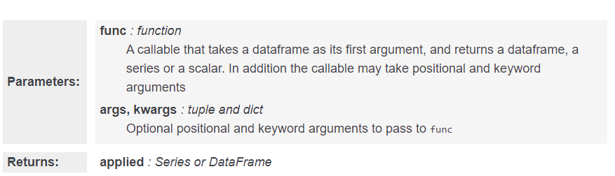

```python
df = pd.DataFrame({'A': 'a a b'.split(), 'B': [1,2,3], 'C': [4,6, 5]})
g = df.groupby('A')
```

```python
list(g)
```

```
[('a',
     A  B  C
  0  a  1  4
  1  a  2  6),
 ('b',
     A  B  C
  2  b  3  5)]
```

```python
func= lambda x: x*2
g.apply(func)
```

|  | A | B | C |
| --- | --- | --- | --- |
| 0 | aa | 2 | 8 |
| 1 | aa | 4 | 12 |
| 2 | bb | 6 | 10 |

```python
func= lambda x: x*2
g.apply(sum)
```

| A | A | B | C |
| --- | --- | --- | --- |
| a | aa | 3 | 10 |
| b | b | 3 | 5 |

```python
list(g)
```

```
[('a',
     A  B  C
  0  a  1  4
  1  a  2  6),
 ('b',
     A  B  C
  2  b  3  5)]
```

```python
def sum_1(a,b=1):
    return a+b
```

```python
g.apply(sum_1,2)
```

|  | B | C |
| --- | --- | --- |
| 0 | 3 | 6 |
| 1 | 4 | 8 |
| 2 | 5 | 7 |

```python
import pandas as pd
import numpy as np

ipl_data = {'Team': ['Riders', 'Riders', 'Devils', 'Devils', 'Kings',
   'kings', 'Kings', 'Kings', 'Riders', 'Royals', 'Royals', 'Riders'],
   'Rank': [1, 2, 2, 3, 3,4 ,1 ,1,2 , 4,1,2],
   'Year': [2014,2015,2014,2015,2014,2015,2016,2017,2016,2014,2015,2017],
   'Points':[876,789,863,673,741,812,756,788,694,701,804,690]}
df = pd.DataFrame(ipl_data)

grouped = df.groupby('Team')
score = lambda x: (x - x.mean()) / x.std()*10
print (grouped.apply(score))
```

```
         Rank       Year     Points
0  -15.000000 -11.618950  12.843272
1    5.000000  -3.872983   3.020286
2   -7.071068  -7.071068   7.071068
3    7.071068   7.071068  -7.071068
4   11.547005 -10.910895  -8.608621
5         NaN        NaN        NaN
6   -5.773503   2.182179  -2.360428
7   -5.773503   8.728716  10.969049
8    5.000000   3.872983  -7.705963
9    7.071068  -7.071068  -7.071068
10  -7.071068   7.071068   7.071068
11   5.000000  11.618950  -8.157595
```

```python
import pandas as pd
import numpy as np

ipl_data = {'Team': ['Riders', 'Riders', 'Devils', 'Devils', 'Kings',
   'kings', 'Kings', 'Kings', 'Riders', 'Royals', 'Royals', 'Riders'],
   'Rank': [1, 2, 2, 3, 3,4 ,1 ,1,2 , 4,1,2],
   'Year': [2014,2015,2014,2015,2014,2015,2016,2017,2016,2014,2015,2017],
   'Points':[876,789,863,673,741,812,756,788,694,701,804,690]}
df = pd.DataFrame(ipl_data)

grouped = df.groupby('Team')
score = lambda x: (x - x.mean()) / x.std()*10
print (grouped.transform(score))
```

```
         Rank       Year     Points
0  -15.000000 -11.618950  12.843272
1    5.000000  -3.872983   3.020286
2   -7.071068  -7.071068   7.071068
3    7.071068   7.071068  -7.071068
4   11.547005 -10.910895  -8.608621
5         NaN        NaN        NaN
6   -5.773503   2.182179  -2.360428
7   -5.773503   8.728716  10.969049
8    5.000000   3.872983  -7.705963
9    7.071068  -7.071068  -7.071068
10  -7.071068   7.071068   7.071068
11   5.000000  11.618950  -8.157595
```

## 3 Filtration

```
Filtration filters the data on a defined criteria and returns the subset of data. The filter() function is used to filter the data.
```

```python
import pandas as pd
import numpy as np

ipl_data = {'Team': ['Riders', 'Riders', 'Devils', 'Devils', 'Kings',
   'kings', 'Kings', 'Kings', 'Riders', 'Royals', 'Royals', 'Riders'],
   'Rank': [1, 2, 2, 3, 3,4 ,1 ,1,2 , 4,1,2],
   'Year': [2014,2015,2014,2015,2014,2015,2016,2017,2016,2014,2015,2017],
   'Points':[876,789,863,673,741,812,756,788,694,701,804,690]}
df = pd.DataFrame(ipl_data)

print(df.groupby('Team').filter(lambda x: len(x) >= 3))
```

```
      Team  Rank  Year  Points
0   Riders     1  2014     876
1   Riders     2  2015     789
4    Kings     3  2014     741
6    Kings     1  2016     756
7    Kings     1  2017     788
8   Riders     2  2016     694
11  Riders     2  2017     690
```

# Concatenate for combining DataFrames across rows or columns

## Combining Data in Pandas With merge(), .join(), and concat()

Pandas’ Series and DataFrame objects are powerful tools for exploring and analyzing data. Part of their power comes from a multifaceted approach to combining separate datasets. With Pandas, you can merge, join, and concatenate your datasets, allowing you to unify and better understand your data as you analyze it.

In this tutorial, you’ll learn how and when to combine your data in Pandas with:

```
merge() for combining data on common columns or indices
.join() for combining data on a key column or an index
concat() for combining DataFrames across rows or columns
```

# Pandas concat(): Combining Data Across Rows or Columns

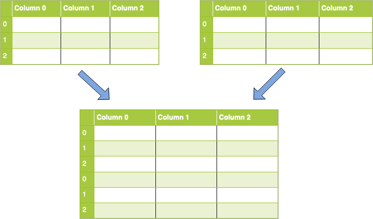

To implement this in code, you’ll use concat() and pass it a list of DataFrames that you want to concatenate. Code for this task would like like this:

### Example1

```python
df1=pd.read_csv("df1.csv",index_col=0)
df1
```

|  | column_a | column_b | column_c |
| --- | --- | --- | --- |
| 0 | 1 | a | True |
| 1 | 2 | b | True |
| 2 | 3 | c | False |
| 3 | 4 | d | True |

```python
df2=pd.read_csv("df2.csv",index_col=0)
df2
```

|  | column_a | column_b | column_c |
| --- | --- | --- | --- |
| 0 | 1 | a | False |
| 1 | 2 | k | False |
| 2 | 9 | r | False |
| 3 | 10 | Q | True |

### concat() function:

- It can be used to concatenate DataFrames along rows or columns by changing the axis parameter.
- The default value of the axis parameter is 0, which indicates combining along rows.

```python
## concatenate df1 & df2 on axis=0 or across rows
conct_axis0= pd.concat([df1,df2])
conct_axis0
```

|  | column_a | column_b | column_c |
| --- | --- | --- | --- |
| 0 | 1 | a | True |
| 1 | 2 | b | True |
| 2 | 3 | c | False |
| 3 | 4 | d | True |
| 0 | 1 | a | False |
| 1 | 2 | k | False |
| 2 | 9 | r | False |
| 3 | 10 | Q | True |

### As you can see above, indices of individual DataFrames are kept. In order to change it and re-index the combined DataFrame,

- ignore_index parameter is set as True

```python
conct_axis0_reset_index= pd.concat([df1,df2],ignore_index=True)
conct_axis0_reset_index
```

|  | column_a | column_b | column_c |
| --- | --- | --- | --- |
| 0 | 1 | a | True |
| 1 | 2 | b | True |
| 2 | 3 | c | False |
| 3 | 4 | d | True |
| 4 | 1 | a | False |
| 5 | 2 | k | False |
| 6 | 9 | r | False |
| 7 | 10 | Q | True |

### concatenate df1 & df2 across columns ( axis=1)

```python
## concatenate df1 & df2 on axis=1 or across columns
conct_axis1= pd.concat([df1,df2],axis=1)
conct_axis1
```

|  | column_a | column_b | column_c | column_a | column_b | column_c |
| --- | --- | --- | --- | --- | --- | --- |
| 0 | 1 | a | True | 1 | a | False |
| 1 | 2 | b | True | 2 | k | False |
| 2 | 3 | c | False | 9 | r | False |
| 3 | 4 | d | True | 10 | Q | True |

### join parameter of concat()

```
    function determines how to combine DataFrames. The default value is ‘outer’ returns all indices in both DataFrames. If ‘inner’ option is selected, only the rows with shared indices are returned. I will change the index of df2 so that you can see the difference between ‘inner’ and ‘outer’.
```

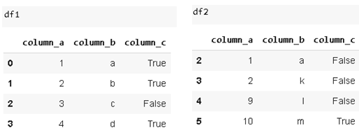

```python
df1
```

|  | column_a | column_b | column_c |
| --- | --- | --- | --- |
| 0 | 1 | a | True |
| 1 | 2 | b | True |
| 2 | 3 | c | False |
| 3 | 4 | d | True |

```python
df2.index=[2,3,4,5]
df2
```

|  | column_a | column_b | column_c |
| --- | --- | --- | --- |
| 2 | 1 | a | False |
| 3 | 2 | k | False |
| 4 | 9 | r | False |
| 5 | 10 | Q | True |

### inner join

```python
df1_df2_innerjoin=pd.concat([df1,df2],axis=1,join="inner")
df1_df2_innerjoin
```

|  | column_a | column_b | column_c | column_a | column_b | column_c |
| --- | --- | --- | --- | --- | --- | --- |
| 2 | 3 | c | False | 1 | a | False |
| 3 | 4 | d | True | 2 | k | False |

### Outer join

```python
df1_df2_OUTERjoin=pd.concat([df1,df2],axis=1,join="outer")
df1_df2_OUTERjoin
```

|  | column_a | column_b | column_c | column_a | column_b | column_c |
| --- | --- | --- | --- | --- | --- | --- |
| 0 | 1.0 | a | True | NaN | NaN | NaN |
| 1 | 2.0 | b | True | NaN | NaN | NaN |
| 2 | 3.0 | c | False | 1.0 | a | False |
| 3 | 4.0 | d | True | 2.0 | k | False |
| 4 | NaN | NaN | NaN | 9.0 | r | False |
| 5 | NaN | NaN | NaN | 10.0 | Q | True |

### keys

```python
df1_df2_keys=pd.concat([df1,df2],keys=["df1","df2"])
df1_df2_keys
```

|  |  | column_a | column_b | column_c |
| --- | --- | --- | --- | --- |
| df1 | 0 | 1 | a | True |
|  | 1 | 2 | b | True |
|  | 2 | 3 | c | False |
|  | 3 | 4 | d | True |
| df2 | 2 | 1 | a | False |
|  | 3 | 2 | k | False |
|  | 4 | 9 | r | False |
|  | 5 | 10 | Q | True |

```python
df1_df2_keys_names=pd.concat([df1,df2],keys=["df1","df2"],names=['Series name', 'Row ID'])
df1_df2_keys_names
```

| Series name | Row ID | column_a | column_b | column_c |
| --- | --- | --- | --- | --- |
| df1 | 0 | 1 | a | True |
|  | 1 | 2 | b | True |
|  | 2 | 3 | c | False |
|  | 3 | 4 | d | True |
| df2 | 2 | 1 | a | False |
|  | 3 | 2 | k | False |
|  | 4 | 9 | r | False |
|  | 5 | 10 | Q | True |

```python
df1_df2_keys.loc["df1"]
```

|  | column_a | column_b | column_c |
| --- | --- | --- | --- |
| 0 | 1 | a | True |
| 1 | 2 | b | True |
| 2 | 3 | c | False |
| 3 | 4 | d | True |

### example 2

```python
import pandas as pd
climate_temp = pd.read_csv("dataset/climate_temp.csv")
climate_precip = pd.read_csv("dataset/climate_precip.csv")
```

```python
double_precip = pd.concat([climate_temp, climate_precip])
double_precip
```

|  | STATION | STATION_NAME | ELEVATION | LATITUDE | LONGITUDE | DATE | DLY-CLDD-BASE45 | DLY-CLDD-BASE50 | DLY-CLDD-BASE55 | DLY-CLDD-BASE57 | ... | DLY-PRCP-PCTALL-GE100HI | DLY-SNWD-PCTALL-GE001WI | DLY-SNWD-PCTALL-GE010WI | DLY-SNWD-PCTALL-GE003WI | DLY-SNWD-PCTALL-GE005WI | DLY-SNOW-PCTALL-GE001TI | DLY-SNOW-PCTALL-GE010TI | DLY-SNOW-PCTALL-GE100TI | DLY-SNOW-PCTALL-GE030TI | DLY-SNOW-PCTALL-GE050TI |
| --- | --- | --- | --- | --- | --- | --- | --- | --- | --- | --- | --- | --- | --- | --- | --- | --- | --- | --- | --- | --- | --- |
| 0 | GHCND:USC00049099 | TWENTYNINE PALMS CA US | 602 | 34.12806 | -116.03694 | 20100101 | 6.0 | 2.0 | -7777.0 | -7777.0 | ... | NaN | NaN | NaN | NaN | NaN | NaN | NaN | NaN | NaN | NaN |
| 1 | GHCND:USC00049099 | TWENTYNINE PALMS CA US | 602 | 34.12806 | -116.03694 | 20100102 | 6.0 | 2.0 | 1.0 | -7777.0 | ... | NaN | NaN | NaN | NaN | NaN | NaN | NaN | NaN | NaN | NaN |
| 2 | GHCND:USC00049099 | TWENTYNINE PALMS CA US | 602 | 34.12806 | -116.03694 | 20100103 | 6.0 | 2.0 | 1.0 | -7777.0 | ... | NaN | NaN | NaN | NaN | NaN | NaN | NaN | NaN | NaN | NaN |
| 3 | GHCND:USC00049099 | TWENTYNINE PALMS CA US | 602 | 34.12806 | -116.03694 | 20100104 | 6.0 | 2.0 | 1.0 | -7777.0 | ... | NaN | NaN | NaN | NaN | NaN | NaN | NaN | NaN | NaN | NaN |
| 4 | GHCND:USC00049099 | TWENTYNINE PALMS CA US | 602 | 34.12806 | -116.03694 | 20100105 | 6.0 | 2.0 | 1.0 | -7777.0 | ... | NaN | NaN | NaN | NaN | NaN | NaN | NaN | NaN | NaN | NaN |
| ... | ... | ... | ... | ... | ... | ... | ... | ... | ... | ... | ... | ... | ... | ... | ... | ... | ... | ... | ... | ... | ... |
| 151105 | GHCND:USC00046006 | MOUNT WILSON CBS CA US | NaN | NaN | NaN | 20101227 | NaN | NaN | NaN | NaN | ... | 62.0 | -9999.0 | -9999.0 | -9999.0 | -9999.0 | -9999.0 | -9999.0 | -9999.0 | -9999.0 | -9999.0 |
| 151106 | GHCND:USC00046006 | MOUNT WILSON CBS CA US | NaN | NaN | NaN | 20101228 | NaN | NaN | NaN | NaN | ... | 62.0 | -9999.0 | -9999.0 | -9999.0 | -9999.0 | -9999.0 | -9999.0 | -9999.0 | -9999.0 | -9999.0 |
| 151107 | GHCND:USC00046006 | MOUNT WILSON CBS CA US | NaN | NaN | NaN | 20101229 | NaN | NaN | NaN | NaN | ... | 63.0 | -9999.0 | -9999.0 | -9999.0 | -9999.0 | -9999.0 | -9999.0 | -9999.0 | -9999.0 | -9999.0 |
| 151108 | GHCND:USC00046006 | MOUNT WILSON CBS CA US | NaN | NaN | NaN | 20101230 | NaN | NaN | NaN | NaN | ... | 64.0 | -9999.0 | -9999.0 | -9999.0 | -9999.0 | -9999.0 | -9999.0 | -9999.0 | -9999.0 | -9999.0 |
| 151109 | GHCND:USC00046006 | MOUNT WILSON CBS CA US | NaN | NaN | NaN | 20101231 | NaN | NaN | NaN | NaN | ... | 64.0 | -9999.0 | -9999.0 | -9999.0 | -9999.0 | -9999.0 | -9999.0 | -9999.0 | -9999.0 | -9999.0 |

278130 rows × 47 columns

```python
reindexed = pd.concat([climate_temp, climate_precip], ignore_index=True)
reindexed
```

|  | STATION | STATION_NAME | ELEVATION | LATITUDE | LONGITUDE | DATE | DLY-CLDD-BASE45 | DLY-CLDD-BASE50 | DLY-CLDD-BASE55 | DLY-CLDD-BASE57 | ... | DLY-PRCP-PCTALL-GE100HI | DLY-SNWD-PCTALL-GE001WI | DLY-SNWD-PCTALL-GE010WI | DLY-SNWD-PCTALL-GE003WI | DLY-SNWD-PCTALL-GE005WI | DLY-SNOW-PCTALL-GE001TI | DLY-SNOW-PCTALL-GE010TI | DLY-SNOW-PCTALL-GE100TI | DLY-SNOW-PCTALL-GE030TI | DLY-SNOW-PCTALL-GE050TI |
| --- | --- | --- | --- | --- | --- | --- | --- | --- | --- | --- | --- | --- | --- | --- | --- | --- | --- | --- | --- | --- | --- |
| 0 | GHCND:USC00049099 | TWENTYNINE PALMS CA US | 602 | 34.12806 | -116.03694 | 20100101 | 6.0 | 2.0 | -7777.0 | -7777.0 | ... | NaN | NaN | NaN | NaN | NaN | NaN | NaN | NaN | NaN | NaN |
| 1 | GHCND:USC00049099 | TWENTYNINE PALMS CA US | 602 | 34.12806 | -116.03694 | 20100102 | 6.0 | 2.0 | 1.0 | -7777.0 | ... | NaN | NaN | NaN | NaN | NaN | NaN | NaN | NaN | NaN | NaN |
| 2 | GHCND:USC00049099 | TWENTYNINE PALMS CA US | 602 | 34.12806 | -116.03694 | 20100103 | 6.0 | 2.0 | 1.0 | -7777.0 | ... | NaN | NaN | NaN | NaN | NaN | NaN | NaN | NaN | NaN | NaN |
| 3 | GHCND:USC00049099 | TWENTYNINE PALMS CA US | 602 | 34.12806 | -116.03694 | 20100104 | 6.0 | 2.0 | 1.0 | -7777.0 | ... | NaN | NaN | NaN | NaN | NaN | NaN | NaN | NaN | NaN | NaN |
| 4 | GHCND:USC00049099 | TWENTYNINE PALMS CA US | 602 | 34.12806 | -116.03694 | 20100105 | 6.0 | 2.0 | 1.0 | -7777.0 | ... | NaN | NaN | NaN | NaN | NaN | NaN | NaN | NaN | NaN | NaN |
| ... | ... | ... | ... | ... | ... | ... | ... | ... | ... | ... | ... | ... | ... | ... | ... | ... | ... | ... | ... | ... | ... |
| 278125 | GHCND:USC00046006 | MOUNT WILSON CBS CA US | NaN | NaN | NaN | 20101227 | NaN | NaN | NaN | NaN | ... | 62.0 | -9999.0 | -9999.0 | -9999.0 | -9999.0 | -9999.0 | -9999.0 | -9999.0 | -9999.0 | -9999.0 |
| 278126 | GHCND:USC00046006 | MOUNT WILSON CBS CA US | NaN | NaN | NaN | 20101228 | NaN | NaN | NaN | NaN | ... | 62.0 | -9999.0 | -9999.0 | -9999.0 | -9999.0 | -9999.0 | -9999.0 | -9999.0 | -9999.0 | -9999.0 |
| 278127 | GHCND:USC00046006 | MOUNT WILSON CBS CA US | NaN | NaN | NaN | 20101229 | NaN | NaN | NaN | NaN | ... | 63.0 | -9999.0 | -9999.0 | -9999.0 | -9999.0 | -9999.0 | -9999.0 | -9999.0 | -9999.0 | -9999.0 |
| 278128 | GHCND:USC00046006 | MOUNT WILSON CBS CA US | NaN | NaN | NaN | 20101230 | NaN | NaN | NaN | NaN | ... | 64.0 | -9999.0 | -9999.0 | -9999.0 | -9999.0 | -9999.0 | -9999.0 | -9999.0 | -9999.0 | -9999.0 |
| 278129 | GHCND:USC00046006 | MOUNT WILSON CBS CA US | NaN | NaN | NaN | 20101231 | NaN | NaN | NaN | NaN | ... | 64.0 | -9999.0 | -9999.0 | -9999.0 | -9999.0 | -9999.0 | -9999.0 | -9999.0 | -9999.0 | -9999.0 |

278130 rows × 47 columns

```python
outer_joined = pd.concat([climate_precip, climate_temp])
outer_joined
```

|  | STATION | STATION_NAME | DATE | DLY-PRCP-25PCTL | DLY-SNWD-25PCTL | DLY-SNOW-25PCTL | DLY-PRCP-50PCTL | DLY-SNWD-50PCTL | DLY-SNOW-50PCTL | DLY-PRCP-75PCTL | ... | DLY-CLDD-NORMAL | DLY-CLDD-BASE70 | DLY-CLDD-BASE72 | DLY-HTDD-BASE40 | DLY-HTDD-BASE45 | DLY-HTDD-BASE50 | DLY-HTDD-BASE55 | DLY-HTDD-BASE57 | DLY-HTDD-BASE60 | DLY-HTDD-NORMAL |
| --- | --- | --- | --- | --- | --- | --- | --- | --- | --- | --- | --- | --- | --- | --- | --- | --- | --- | --- | --- | --- | --- |
| 0 | GHCND:USC00049099 | TWENTYNINE PALMS CA US | 20100101 | -6.66 | -666.0 | -66.6 | -6.66 | -666.0 | -66.6 | -6.66 | ... | NaN | NaN | NaN | NaN | NaN | NaN | NaN | NaN | NaN | NaN |
| 1 | GHCND:USC00049099 | TWENTYNINE PALMS CA US | 20100102 | -6.66 | -666.0 | -66.6 | -6.66 | -666.0 | -66.6 | -6.66 | ... | NaN | NaN | NaN | NaN | NaN | NaN | NaN | NaN | NaN | NaN |
| 2 | GHCND:USC00049099 | TWENTYNINE PALMS CA US | 20100103 | -6.66 | -666.0 | -66.6 | -6.66 | -666.0 | -66.6 | -6.66 | ... | NaN | NaN | NaN | NaN | NaN | NaN | NaN | NaN | NaN | NaN |
| 3 | GHCND:USC00049099 | TWENTYNINE PALMS CA US | 20100104 | -6.66 | -9999.0 | -9999.0 | -6.66 | -9999.0 | -9999.0 | -6.66 | ... | NaN | NaN | NaN | NaN | NaN | NaN | NaN | NaN | NaN | NaN |
| 4 | GHCND:USC00049099 | TWENTYNINE PALMS CA US | 20100105 | -6.66 | -9999.0 | -9999.0 | -6.66 | -9999.0 | -9999.0 | -6.66 | ... | NaN | NaN | NaN | NaN | NaN | NaN | NaN | NaN | NaN | NaN |
| ... | ... | ... | ... | ... | ... | ... | ... | ... | ... | ... | ... | ... | ... | ... | ... | ... | ... | ... | ... | ... | ... |
| 127015 | GHCND:USC00046006 | MOUNT WILSON CBS CA US | 20101227 | NaN | NaN | NaN | NaN | NaN | NaN | NaN | ... | -7777.0 | 0.0 | 0.0 | 2.0 | 4.0 | 6.0 | 10.0 | 12.0 | 15.0 | 20.0 |
| 127016 | GHCND:USC00046006 | MOUNT WILSON CBS CA US | 20101228 | NaN | NaN | NaN | NaN | NaN | NaN | NaN | ... | -7777.0 | 0.0 | 0.0 | 2.0 | 3.0 | 6.0 | 10.0 | 12.0 | 15.0 | 20.0 |
| 127017 | GHCND:USC00046006 | MOUNT WILSON CBS CA US | 20101229 | NaN | NaN | NaN | NaN | NaN | NaN | NaN | ... | -7777.0 | 0.0 | 0.0 | 2.0 | 3.0 | 6.0 | 10.0 | 12.0 | 15.0 | 19.0 |
| 127018 | GHCND:USC00046006 | MOUNT WILSON CBS CA US | 20101230 | NaN | NaN | NaN | NaN | NaN | NaN | NaN | ... | -7777.0 | 0.0 | 0.0 | 2.0 | 3.0 | 6.0 | 10.0 | 12.0 | 15.0 | 19.0 |
| 127019 | GHCND:USC00046006 | MOUNT WILSON CBS CA US | 20101231 | NaN | NaN | NaN | NaN | NaN | NaN | NaN | ... | -7777.0 | 0.0 | 0.0 | 1.0 | 3.0 | 6.0 | 10.0 | 12.0 | 14.0 | 19.0 |

278130 rows × 47 columns

```python
inner_joined = pd.concat([climate_temp, climate_precip], join="inner")
inner_joined
```

|  | STATION | STATION_NAME | DATE |
| --- | --- | --- | --- |
| 0 | GHCND:USC00049099 | TWENTYNINE PALMS CA US | 20100101 |
| 1 | GHCND:USC00049099 | TWENTYNINE PALMS CA US | 20100102 |
| 2 | GHCND:USC00049099 | TWENTYNINE PALMS CA US | 20100103 |
| 3 | GHCND:USC00049099 | TWENTYNINE PALMS CA US | 20100104 |
| 4 | GHCND:USC00049099 | TWENTYNINE PALMS CA US | 20100105 |
| ... | ... | ... | ... |
| 151105 | GHCND:USC00046006 | MOUNT WILSON CBS CA US | 20101227 |
| 151106 | GHCND:USC00046006 | MOUNT WILSON CBS CA US | 20101228 |
| 151107 | GHCND:USC00046006 | MOUNT WILSON CBS CA US | 20101229 |
| 151108 | GHCND:USC00046006 | MOUNT WILSON CBS CA US | 20101230 |
| 151109 | GHCND:USC00046006 | MOUNT WILSON CBS CA US | 20101231 |

278130 rows × 3 columns

```python
inner_joined_cols = pd.concat([climate_temp, climate_precip], axis=1, join="inner")
inner_joined_cols
```

|  | STATION | STATION_NAME | ELEVATION | LATITUDE | LONGITUDE | DATE | DLY-CLDD-BASE45 | DLY-CLDD-BASE50 | DLY-CLDD-BASE55 | DLY-CLDD-BASE57 | ... | DLY-PRCP-PCTALL-GE100HI | DLY-SNWD-PCTALL-GE001WI | DLY-SNWD-PCTALL-GE010WI | DLY-SNWD-PCTALL-GE003WI | DLY-SNWD-PCTALL-GE005WI | DLY-SNOW-PCTALL-GE001TI | DLY-SNOW-PCTALL-GE010TI | DLY-SNOW-PCTALL-GE100TI | DLY-SNOW-PCTALL-GE030TI | DLY-SNOW-PCTALL-GE050TI |
| --- | --- | --- | --- | --- | --- | --- | --- | --- | --- | --- | --- | --- | --- | --- | --- | --- | --- | --- | --- | --- | --- |
| 0 | GHCND:USC00049099 | TWENTYNINE PALMS CA US | 602 | 34.12806 | -116.03694 | 20100101 | 6 | 2 | -7777 | -7777 | ... | 3 | -9999 | 0 | -9999 | -9999 | -9999 | -9999 | 0 | -9999 | -9999 |
| 1 | GHCND:USC00049099 | TWENTYNINE PALMS CA US | 602 | 34.12806 | -116.03694 | 20100102 | 6 | 2 | 1 | -7777 | ... | 3 | -9999 | 0 | -9999 | -9999 | -9999 | -9999 | 0 | -9999 | -9999 |
| 2 | GHCND:USC00049099 | TWENTYNINE PALMS CA US | 602 | 34.12806 | -116.03694 | 20100103 | 6 | 2 | 1 | -7777 | ... | 3 | -9999 | 0 | -9999 | -9999 | -9999 | -9999 | 0 | -9999 | -9999 |
| 3 | GHCND:USC00049099 | TWENTYNINE PALMS CA US | 602 | 34.12806 | -116.03694 | 20100104 | 6 | 2 | 1 | -7777 | ... | 3 | 0 | 0 | 0 | 0 | 0 | 0 | 0 | 0 | 0 |
| 4 | GHCND:USC00049099 | TWENTYNINE PALMS CA US | 602 | 34.12806 | -116.03694 | 20100105 | 6 | 2 | 1 | -7777 | ... | 3 | 0 | 0 | 0 | 0 | 0 | 0 | 0 | 0 | 0 |
| ... | ... | ... | ... | ... | ... | ... | ... | ... | ... | ... | ... | ... | ... | ... | ... | ... | ... | ... | ... | ... | ... |
| 127015 | GHCND:USC00046006 | MOUNT WILSON CBS CA US | 1740.4 | 34.2308 | -118.0711 | 20101227 | 4 | 2 | 1 | -7777 | ... | 15 | 0 | 0 | 0 | 0 | 0 | 0 | 0 | 0 | 0 |
| 127016 | GHCND:USC00046006 | MOUNT WILSON CBS CA US | 1740.4 | 34.2308 | -118.0711 | 20101228 | 4 | 2 | 1 | -7777 | ... | 15 | 0 | 0 | 0 | 0 | 0 | 0 | 0 | 0 | 0 |
| 127017 | GHCND:USC00046006 | MOUNT WILSON CBS CA US | 1740.4 | 34.2308 | -118.0711 | 20101229 | 4 | 2 | 1 | -7777 | ... | 16 | 0 | 0 | 0 | 0 | 0 | 0 | 0 | 0 | 0 |
| 127018 | GHCND:USC00046006 | MOUNT WILSON CBS CA US | 1740.4 | 34.2308 | -118.0711 | 20101230 | 4 | 2 | 1 | -7777 | ... | 16 | 0 | 0 | 0 | 0 | 0 | 0 | 0 | 0 | 0 |
| 127019 | GHCND:USC00046006 | MOUNT WILSON CBS CA US | 1740.4 | 34.2308 | -118.0711 | 20101231 | 4 | 2 | 1 | -7777 | ... | 16 | 0 | 0 | 0 | 0 | 0 | 0 | 0 | 0 | 0 |

127020 rows × 50 columns

```python
hierarchical_keys = pd.concat([climate_temp, climate_precip], keys=["temp", "precip"])
hierarchical_keys
```

|  |  | STATION | STATION_NAME | ELEVATION | LATITUDE | LONGITUDE | DATE | DLY-CLDD-BASE45 | DLY-CLDD-BASE50 | DLY-CLDD-BASE55 | DLY-CLDD-BASE57 | ... | DLY-PRCP-PCTALL-GE100HI | DLY-SNWD-PCTALL-GE001WI | DLY-SNWD-PCTALL-GE010WI | DLY-SNWD-PCTALL-GE003WI | DLY-SNWD-PCTALL-GE005WI | DLY-SNOW-PCTALL-GE001TI | DLY-SNOW-PCTALL-GE010TI | DLY-SNOW-PCTALL-GE100TI | DLY-SNOW-PCTALL-GE030TI | DLY-SNOW-PCTALL-GE050TI |
| --- | --- | --- | --- | --- | --- | --- | --- | --- | --- | --- | --- | --- | --- | --- | --- | --- | --- | --- | --- | --- | --- | --- |
| temp | 0 | GHCND:USC00049099 | TWENTYNINE PALMS CA US | 602 | 34.12806 | -116.03694 | 20100101 | 6.0 | 2.0 | -7777.0 | -7777.0 | ... | NaN | NaN | NaN | NaN | NaN | NaN | NaN | NaN | NaN | NaN |
|  | 1 | GHCND:USC00049099 | TWENTYNINE PALMS CA US | 602 | 34.12806 | -116.03694 | 20100102 | 6.0 | 2.0 | 1.0 | -7777.0 | ... | NaN | NaN | NaN | NaN | NaN | NaN | NaN | NaN | NaN | NaN |
|  | 2 | GHCND:USC00049099 | TWENTYNINE PALMS CA US | 602 | 34.12806 | -116.03694 | 20100103 | 6.0 | 2.0 | 1.0 | -7777.0 | ... | NaN | NaN | NaN | NaN | NaN | NaN | NaN | NaN | NaN | NaN |
|  | 3 | GHCND:USC00049099 | TWENTYNINE PALMS CA US | 602 | 34.12806 | -116.03694 | 20100104 | 6.0 | 2.0 | 1.0 | -7777.0 | ... | NaN | NaN | NaN | NaN | NaN | NaN | NaN | NaN | NaN | NaN |
|  | 4 | GHCND:USC00049099 | TWENTYNINE PALMS CA US | 602 | 34.12806 | -116.03694 | 20100105 | 6.0 | 2.0 | 1.0 | -7777.0 | ... | NaN | NaN | NaN | NaN | NaN | NaN | NaN | NaN | NaN | NaN |
| ... | ... | ... | ... | ... | ... | ... | ... | ... | ... | ... | ... | ... | ... | ... | ... | ... | ... | ... | ... | ... | ... | ... |
| precip | 151105 | GHCND:USC00046006 | MOUNT WILSON CBS CA US | NaN | NaN | NaN | 20101227 | NaN | NaN | NaN | NaN | ... | 62.0 | -9999.0 | -9999.0 | -9999.0 | -9999.0 | -9999.0 | -9999.0 | -9999.0 | -9999.0 | -9999.0 |
|  | 151106 | GHCND:USC00046006 | MOUNT WILSON CBS CA US | NaN | NaN | NaN | 20101228 | NaN | NaN | NaN | NaN | ... | 62.0 | -9999.0 | -9999.0 | -9999.0 | -9999.0 | -9999.0 | -9999.0 | -9999.0 | -9999.0 | -9999.0 |
|  | 151107 | GHCND:USC00046006 | MOUNT WILSON CBS CA US | NaN | NaN | NaN | 20101229 | NaN | NaN | NaN | NaN | ... | 63.0 | -9999.0 | -9999.0 | -9999.0 | -9999.0 | -9999.0 | -9999.0 | -9999.0 | -9999.0 | -9999.0 |
|  | 151108 | GHCND:USC00046006 | MOUNT WILSON CBS CA US | NaN | NaN | NaN | 20101230 | NaN | NaN | NaN | NaN | ... | 64.0 | -9999.0 | -9999.0 | -9999.0 | -9999.0 | -9999.0 | -9999.0 | -9999.0 | -9999.0 | -9999.0 |
|  | 151109 | GHCND:USC00046006 | MOUNT WILSON CBS CA US | NaN | NaN | NaN | 20101231 | NaN | NaN | NaN | NaN | ... | 64.0 | -9999.0 | -9999.0 | -9999.0 | -9999.0 | -9999.0 | -9999.0 | -9999.0 | -9999.0 | -9999.0 |

278130 rows × 47 columns

```python
appended = climate_temp.append(climate_precip)
appended
```

|  | STATION | STATION_NAME | ELEVATION | LATITUDE | LONGITUDE | DATE | DLY-CLDD-BASE45 | DLY-CLDD-BASE50 | DLY-CLDD-BASE55 | DLY-CLDD-BASE57 | ... | DLY-PRCP-PCTALL-GE100HI | DLY-SNWD-PCTALL-GE001WI | DLY-SNWD-PCTALL-GE010WI | DLY-SNWD-PCTALL-GE003WI | DLY-SNWD-PCTALL-GE005WI | DLY-SNOW-PCTALL-GE001TI | DLY-SNOW-PCTALL-GE010TI | DLY-SNOW-PCTALL-GE100TI | DLY-SNOW-PCTALL-GE030TI | DLY-SNOW-PCTALL-GE050TI |
| --- | --- | --- | --- | --- | --- | --- | --- | --- | --- | --- | --- | --- | --- | --- | --- | --- | --- | --- | --- | --- | --- |
| 0 | GHCND:USC00049099 | TWENTYNINE PALMS CA US | 602 | 34.12806 | -116.03694 | 20100101 | 6.0 | 2.0 | -7777.0 | -7777.0 | ... | NaN | NaN | NaN | NaN | NaN | NaN | NaN | NaN | NaN | NaN |
| 1 | GHCND:USC00049099 | TWENTYNINE PALMS CA US | 602 | 34.12806 | -116.03694 | 20100102 | 6.0 | 2.0 | 1.0 | -7777.0 | ... | NaN | NaN | NaN | NaN | NaN | NaN | NaN | NaN | NaN | NaN |
| 2 | GHCND:USC00049099 | TWENTYNINE PALMS CA US | 602 | 34.12806 | -116.03694 | 20100103 | 6.0 | 2.0 | 1.0 | -7777.0 | ... | NaN | NaN | NaN | NaN | NaN | NaN | NaN | NaN | NaN | NaN |
| 3 | GHCND:USC00049099 | TWENTYNINE PALMS CA US | 602 | 34.12806 | -116.03694 | 20100104 | 6.0 | 2.0 | 1.0 | -7777.0 | ... | NaN | NaN | NaN | NaN | NaN | NaN | NaN | NaN | NaN | NaN |
| 4 | GHCND:USC00049099 | TWENTYNINE PALMS CA US | 602 | 34.12806 | -116.03694 | 20100105 | 6.0 | 2.0 | 1.0 | -7777.0 | ... | NaN | NaN | NaN | NaN | NaN | NaN | NaN | NaN | NaN | NaN |
| ... | ... | ... | ... | ... | ... | ... | ... | ... | ... | ... | ... | ... | ... | ... | ... | ... | ... | ... | ... | ... | ... |
| 151105 | GHCND:USC00046006 | MOUNT WILSON CBS CA US | NaN | NaN | NaN | 20101227 | NaN | NaN | NaN | NaN | ... | 62.0 | -9999.0 | -9999.0 | -9999.0 | -9999.0 | -9999.0 | -9999.0 | -9999.0 | -9999.0 | -9999.0 |
| 151106 | GHCND:USC00046006 | MOUNT WILSON CBS CA US | NaN | NaN | NaN | 20101228 | NaN | NaN | NaN | NaN | ... | 62.0 | -9999.0 | -9999.0 | -9999.0 | -9999.0 | -9999.0 | -9999.0 | -9999.0 | -9999.0 | -9999.0 |
| 151107 | GHCND:USC00046006 | MOUNT WILSON CBS CA US | NaN | NaN | NaN | 20101229 | NaN | NaN | NaN | NaN | ... | 63.0 | -9999.0 | -9999.0 | -9999.0 | -9999.0 | -9999.0 | -9999.0 | -9999.0 | -9999.0 | -9999.0 |
| 151108 | GHCND:USC00046006 | MOUNT WILSON CBS CA US | NaN | NaN | NaN | 20101230 | NaN | NaN | NaN | NaN | ... | 64.0 | -9999.0 | -9999.0 | -9999.0 | -9999.0 | -9999.0 | -9999.0 | -9999.0 | -9999.0 | -9999.0 |
| 151109 | GHCND:USC00046006 | MOUNT WILSON CBS CA US | NaN | NaN | NaN | 20101231 | NaN | NaN | NaN | NaN | ... | 64.0 | -9999.0 | -9999.0 | -9999.0 | -9999.0 | -9999.0 | -9999.0 | -9999.0 | -9999.0 | -9999.0 |

278130 rows × 47 columns

When you use merge(), you’ll provide two required arguments:

```
The left DataFrame
The right DataFrame
```

How to merge() Before getting into the details of how to use merge(), you should first understand the various forms of joins:

```
inner
outer
left
right
```

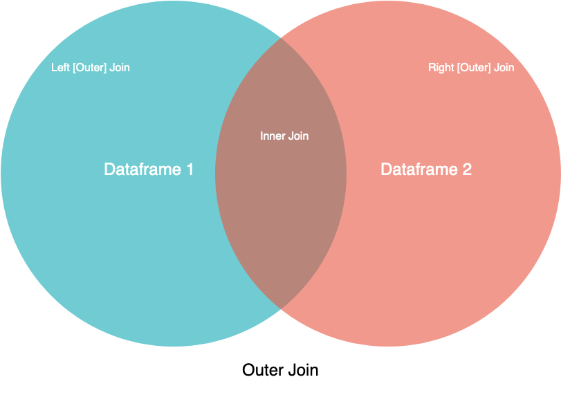

## Inner Join

you will lose rows that don’t have a match in the other DataFrame’s key column.

```python
import pandas as pd
climate_temp = pd.read_csv("dataset/climate_temp.csv")
climate_precip = pd.read_csv("dataset/climate_precip.csv")
```

```python
climate_temp.head()
```

|  | STATION | STATION_NAME | ELEVATION | LATITUDE | LONGITUDE | DATE | DLY-CLDD-BASE45 | DLY-CLDD-BASE50 | DLY-CLDD-BASE55 | DLY-CLDD-BASE57 | ... | DLY-CLDD-NORMAL | DLY-CLDD-BASE70 | DLY-CLDD-BASE72 | DLY-HTDD-BASE40 | DLY-HTDD-BASE45 | DLY-HTDD-BASE50 | DLY-HTDD-BASE55 | DLY-HTDD-BASE57 | DLY-HTDD-BASE60 | DLY-HTDD-NORMAL |
| --- | --- | --- | --- | --- | --- | --- | --- | --- | --- | --- | --- | --- | --- | --- | --- | --- | --- | --- | --- | --- | --- |
| 0 | GHCND:USC00049099 | TWENTYNINE PALMS CA US | 602 | 34.12806 | -116.03694 | 20100101 | 6 | 2 | -7777 | -7777 | ... | 0 | 0 | 0 | -7777 | 1 | 2 | 6 | 7 | 10 | 15 |
| 1 | GHCND:USC00049099 | TWENTYNINE PALMS CA US | 602 | 34.12806 | -116.03694 | 20100102 | 6 | 2 | 1 | -7777 | ... | 0 | 0 | 0 | -7777 | 1 | 2 | 6 | 7 | 10 | 15 |
| 2 | GHCND:USC00049099 | TWENTYNINE PALMS CA US | 602 | 34.12806 | -116.03694 | 20100103 | 6 | 2 | 1 | -7777 | ... | 0 | 0 | 0 | -7777 | 1 | 2 | 5 | 7 | 10 | 15 |
| 3 | GHCND:USC00049099 | TWENTYNINE PALMS CA US | 602 | 34.12806 | -116.03694 | 20100104 | 6 | 2 | 1 | -7777 | ... | 0 | 0 | 0 | -7777 | 1 | 2 | 5 | 7 | 10 | 15 |
| 4 | GHCND:USC00049099 | TWENTYNINE PALMS CA US | 602 | 34.12806 | -116.03694 | 20100105 | 6 | 2 | 1 | -7777 | ... | 0 | 0 | 0 | -7777 | -7777 | 2 | 5 | 7 | 10 | 15 |

5 rows × 21 columns

```python
climate_precip.head()
```

|  | STATION | STATION_NAME | DATE | DLY-PRCP-25PCTL | DLY-SNWD-25PCTL | DLY-SNOW-25PCTL | DLY-PRCP-50PCTL | DLY-SNWD-50PCTL | DLY-SNOW-50PCTL | DLY-PRCP-75PCTL | ... | DLY-PRCP-PCTALL-GE100HI | DLY-SNWD-PCTALL-GE001WI | DLY-SNWD-PCTALL-GE010WI | DLY-SNWD-PCTALL-GE003WI | DLY-SNWD-PCTALL-GE005WI | DLY-SNOW-PCTALL-GE001TI | DLY-SNOW-PCTALL-GE010TI | DLY-SNOW-PCTALL-GE100TI | DLY-SNOW-PCTALL-GE030TI | DLY-SNOW-PCTALL-GE050TI |
| --- | --- | --- | --- | --- | --- | --- | --- | --- | --- | --- | --- | --- | --- | --- | --- | --- | --- | --- | --- | --- | --- |
| 0 | GHCND:USC00049099 | TWENTYNINE PALMS CA US | 20100101 | -6.66 | -666 | -66.6 | -6.66 | -666 | -66.6 | -6.66 | ... | 3 | -9999 | 0 | -9999 | -9999 | -9999 | -9999 | 0 | -9999 | -9999 |
| 1 | GHCND:USC00049099 | TWENTYNINE PALMS CA US | 20100102 | -6.66 | -666 | -66.6 | -6.66 | -666 | -66.6 | -6.66 | ... | 3 | -9999 | 0 | -9999 | -9999 | -9999 | -9999 | 0 | -9999 | -9999 |
| 2 | GHCND:USC00049099 | TWENTYNINE PALMS CA US | 20100103 | -6.66 | -666 | -66.6 | -6.66 | -666 | -66.6 | -6.66 | ... | 3 | -9999 | 0 | -9999 | -9999 | -9999 | -9999 | 0 | -9999 | -9999 |
| 3 | GHCND:USC00049099 | TWENTYNINE PALMS CA US | 20100104 | -6.66 | -9999 | -9999.0 | -6.66 | -9999 | -9999.0 | -6.66 | ... | 3 | 0 | 0 | 0 | 0 | 0 | 0 | 0 | 0 | 0 |
| 4 | GHCND:USC00049099 | TWENTYNINE PALMS CA US | 20100105 | -6.66 | -9999 | -9999.0 | -6.66 | -9999 | -9999.0 | -6.66 | ... | 3 | 0 | 0 | 0 | 0 | 0 | 0 | 0 | 0 | 0 |

5 rows × 29 columns

```python
climate_temp.shape
```

```
(127020, 21)
```

```python
climate_precip.shape
```

```
(151110, 29)
```

```python
precip_one_station = climate_precip[climate_precip["STATION"] == "GHCND:USC00045721"]
```

```python
precip_one_station.head()
```

|  | STATION | STATION_NAME | DATE | DLY-PRCP-25PCTL | DLY-SNWD-25PCTL | DLY-SNOW-25PCTL | DLY-PRCP-50PCTL | DLY-SNWD-50PCTL | DLY-SNOW-50PCTL | DLY-PRCP-75PCTL | ... | DLY-PRCP-PCTALL-GE100HI | DLY-SNWD-PCTALL-GE001WI | DLY-SNWD-PCTALL-GE010WI | DLY-SNWD-PCTALL-GE003WI | DLY-SNWD-PCTALL-GE005WI | DLY-SNOW-PCTALL-GE001TI | DLY-SNOW-PCTALL-GE010TI | DLY-SNOW-PCTALL-GE100TI | DLY-SNOW-PCTALL-GE030TI | DLY-SNOW-PCTALL-GE050TI |
| --- | --- | --- | --- | --- | --- | --- | --- | --- | --- | --- | --- | --- | --- | --- | --- | --- | --- | --- | --- | --- | --- |
| 1460 | GHCND:USC00045721 | MITCHELL CAVERNS CA US | 20100101 | 0.04 | -666 | -66.6 | 0.16 | -666 | -66.6 | 0.44 | ... | 11 | 4 | 0 | 3 | 3 | 9 | 6 | 0 | -9999 | -9999 |
| 1461 | GHCND:USC00045721 | MITCHELL CAVERNS CA US | 20100102 | 0.05 | -666 | -66.6 | 0.16 | -666 | -66.6 | 0.44 | ... | 11 | 4 | 0 | 3 | 3 | 10 | 6 | 0 | -9999 | -9999 |
| 1462 | GHCND:USC00045721 | MITCHELL CAVERNS CA US | 20100103 | 0.05 | -666 | -66.6 | 0.16 | -666 | -66.6 | 0.45 | ... | 11 | 4 | 0 | 3 | 3 | 10 | 6 | 0 | -9999 | -9999 |
| 1463 | GHCND:USC00045721 | MITCHELL CAVERNS CA US | 20100104 | 0.05 | -666 | -66.6 | 0.16 | -666 | -66.6 | 0.45 | ... | 11 | 4 | 0 | 3 | 2 | 10 | 6 | 0 | -9999 | -9999 |
| 1464 | GHCND:USC00045721 | MITCHELL CAVERNS CA US | 20100105 | 0.05 | -666 | -66.6 | 0.17 | -666 | -66.6 | 0.46 | ... | 11 | 4 | 0 | 3 | 2 | 10 | 6 | 0 | -9999 | -9999 |

5 rows × 29 columns

```python
inner_merged = pd.merge(precip_one_station, climate_temp)
```

```python
inner_merged.head()
```

|  | STATION | STATION_NAME | DATE | DLY-PRCP-25PCTL | DLY-SNWD-25PCTL | DLY-SNOW-25PCTL | DLY-PRCP-50PCTL | DLY-SNWD-50PCTL | DLY-SNOW-50PCTL | DLY-PRCP-75PCTL | ... | DLY-CLDD-NORMAL | DLY-CLDD-BASE70 | DLY-CLDD-BASE72 | DLY-HTDD-BASE40 | DLY-HTDD-BASE45 | DLY-HTDD-BASE50 | DLY-HTDD-BASE55 | DLY-HTDD-BASE57 | DLY-HTDD-BASE60 | DLY-HTDD-NORMAL |
| --- | --- | --- | --- | --- | --- | --- | --- | --- | --- | --- | --- | --- | --- | --- | --- | --- | --- | --- | --- | --- | --- |
| 0 | GHCND:USC00045721 | MITCHELL CAVERNS CA US | 20100101 | 0.04 | -666 | -66.6 | 0.16 | -666 | -66.6 | 0.44 | ... | 0 | 0 | 0 | 1 | 3 | 6 | 10 | 12 | 14 | 19 |
| 1 | GHCND:USC00045721 | MITCHELL CAVERNS CA US | 20100102 | 0.05 | -666 | -66.6 | 0.16 | -666 | -66.6 | 0.44 | ... | 0 | 0 | 0 | 1 | 3 | 6 | 10 | 11 | 14 | 19 |
| 2 | GHCND:USC00045721 | MITCHELL CAVERNS CA US | 20100103 | 0.05 | -666 | -66.6 | 0.16 | -666 | -66.6 | 0.45 | ... | 0 | 0 | 0 | 1 | 2 | 5 | 9 | 11 | 14 | 19 |
| 3 | GHCND:USC00045721 | MITCHELL CAVERNS CA US | 20100104 | 0.05 | -666 | -66.6 | 0.16 | -666 | -66.6 | 0.45 | ... | 0 | 0 | 0 | 1 | 2 | 5 | 9 | 11 | 14 | 19 |
| 4 | GHCND:USC00045721 | MITCHELL CAVERNS CA US | 20100105 | 0.05 | -666 | -66.6 | 0.17 | -666 | -66.6 | 0.46 | ... | 0 | 0 | 0 | 1 | 2 | 5 | 9 | 11 | 14 | 19 |

5 rows × 47 columns

```python
inner_merged.shape
```

```
(365, 47)
```

```python
inner_merged_total = pd.merge(climate_temp, climate_precip, on=["STATION", "DATE"])
inner_merged_total
##inner_merged_total.shape
```

|  | STATION | STATION_NAME_x | ELEVATION | LATITUDE | LONGITUDE | DATE | DLY-CLDD-BASE45 | DLY-CLDD-BASE50 | DLY-CLDD-BASE55 | DLY-CLDD-BASE57 | ... | DLY-PRCP-PCTALL-GE100HI | DLY-SNWD-PCTALL-GE001WI | DLY-SNWD-PCTALL-GE010WI | DLY-SNWD-PCTALL-GE003WI | DLY-SNWD-PCTALL-GE005WI | DLY-SNOW-PCTALL-GE001TI | DLY-SNOW-PCTALL-GE010TI | DLY-SNOW-PCTALL-GE100TI | DLY-SNOW-PCTALL-GE030TI | DLY-SNOW-PCTALL-GE050TI |
| --- | --- | --- | --- | --- | --- | --- | --- | --- | --- | --- | --- | --- | --- | --- | --- | --- | --- | --- | --- | --- | --- |
| 0 | GHCND:USC00049099 | TWENTYNINE PALMS CA US | 602 | 34.12806 | -116.03694 | 20100101 | 6 | 2 | -7777 | -7777 | ... | 3 | -9999 | 0 | -9999 | -9999 | -9999 | -9999 | 0 | -9999 | -9999 |
| 1 | GHCND:USC00049099 | TWENTYNINE PALMS CA US | 602 | 34.12806 | -116.03694 | 20100102 | 6 | 2 | 1 | -7777 | ... | 3 | -9999 | 0 | -9999 | -9999 | -9999 | -9999 | 0 | -9999 | -9999 |
| 2 | GHCND:USC00049099 | TWENTYNINE PALMS CA US | 602 | 34.12806 | -116.03694 | 20100103 | 6 | 2 | 1 | -7777 | ... | 3 | -9999 | 0 | -9999 | -9999 | -9999 | -9999 | 0 | -9999 | -9999 |
| 3 | GHCND:USC00049099 | TWENTYNINE PALMS CA US | 602 | 34.12806 | -116.03694 | 20100104 | 6 | 2 | 1 | -7777 | ... | 3 | 0 | 0 | 0 | 0 | 0 | 0 | 0 | 0 | 0 |
| 4 | GHCND:USC00049099 | TWENTYNINE PALMS CA US | 602 | 34.12806 | -116.03694 | 20100105 | 6 | 2 | 1 | -7777 | ... | 3 | 0 | 0 | 0 | 0 | 0 | 0 | 0 | 0 | 0 |
| ... | ... | ... | ... | ... | ... | ... | ... | ... | ... | ... | ... | ... | ... | ... | ... | ... | ... | ... | ... | ... | ... |
| 123000 | GHCND:USC00046006 | MOUNT WILSON CBS CA US | 1740.4 | 34.2308 | -118.0711 | 20101227 | 4 | 2 | 1 | -7777 | ... | 62 | -9999 | -9999 | -9999 | -9999 | -9999 | -9999 | -9999 | -9999 | -9999 |
| 123001 | GHCND:USC00046006 | MOUNT WILSON CBS CA US | 1740.4 | 34.2308 | -118.0711 | 20101228 | 4 | 2 | 1 | -7777 | ... | 62 | -9999 | -9999 | -9999 | -9999 | -9999 | -9999 | -9999 | -9999 | -9999 |
| 123002 | GHCND:USC00046006 | MOUNT WILSON CBS CA US | 1740.4 | 34.2308 | -118.0711 | 20101229 | 4 | 2 | 1 | -7777 | ... | 63 | -9999 | -9999 | -9999 | -9999 | -9999 | -9999 | -9999 | -9999 | -9999 |
| 123003 | GHCND:USC00046006 | MOUNT WILSON CBS CA US | 1740.4 | 34.2308 | -118.0711 | 20101230 | 4 | 2 | 1 | -7777 | ... | 64 | -9999 | -9999 | -9999 | -9999 | -9999 | -9999 | -9999 | -9999 | -9999 |
| 123004 | GHCND:USC00046006 | MOUNT WILSON CBS CA US | 1740.4 | 34.2308 | -118.0711 | 20101231 | 4 | 2 | 1 | -7777 | ... | 64 | -9999 | -9999 | -9999 | -9999 | -9999 | -9999 | -9999 | -9999 | -9999 |

123005 rows × 48 columns

## Outer Join

all rows from both DataFrames will be present in the new DataFrame

If a row doesn’t have a match in the other DataFrame (based on the key column[s]), then you won’t lose the row like you would with an inner join. Instead, the row will be in the merged DataFrame with NaN values filled in where appropriate.

```python
outer_merged = pd.merge(precip_one_station, climate_temp, how="outer", on=["STATION", "DATE"])
outer_merged.head()
outer_merged.shape
```

```
(127020, 48)
```

## Left Join

you’ll specify a left join—also known as a left outer join—with the how parameter. Using a left outer join will leave your new merged DataFrame with all rows from the left DataFrame, while discarding rows from the right DataFrame that don’t have a match in the key column of the left DataFrame.

```python
left_merged = pd.merge(climate_temp, precip_one_station,
                        how="left", on=["STATION", "DATE"])
left_merged.head()
left_merged.shape
```

```
(127020, 48)
```

```python
left_merged_reversed = pd.merge(precip_one_station, climate_temp, how="left", on=["STATION", "DATE"])
left_merged_reversed.head()
left_merged_reversed.shape
```

```
(365, 48)
```

## Right Join

The right join (or right outer join) is the mirror-image version of the left join. With this join, all rows from the right DataFrame will be retained, while rows in the left DataFrame without a match in the key column of the right DataFrame will be discarded.

```python
right_merged = pd.merge(precip_one_station, climate_temp, how="right", on=["STATION", "DATE"])
right_merged.head()
right_merged.shape
```

```
(127020, 48)
```

## Pandas .join(): Combining Data on a Column or Index

```python
precip_one_station.join(climate_temp, lsuffix="_left", rsuffix="_right")
```

|  | STATION_left | STATION_NAME_left | DATE_left | DLY-PRCP-25PCTL | DLY-SNWD-25PCTL | DLY-SNOW-25PCTL | DLY-PRCP-50PCTL | DLY-SNWD-50PCTL | DLY-SNOW-50PCTL | DLY-PRCP-75PCTL | ... | DLY-CLDD-NORMAL | DLY-CLDD-BASE70 | DLY-CLDD-BASE72 | DLY-HTDD-BASE40 | DLY-HTDD-BASE45 | DLY-HTDD-BASE50 | DLY-HTDD-BASE55 | DLY-HTDD-BASE57 | DLY-HTDD-BASE60 | DLY-HTDD-NORMAL |
| --- | --- | --- | --- | --- | --- | --- | --- | --- | --- | --- | --- | --- | --- | --- | --- | --- | --- | --- | --- | --- | --- |
| 1460 | GHCND:USC00045721 | MITCHELL CAVERNS CA US | 20100101 | 0.04 | -666 | -66.6 | 0.16 | -666 | -66.6 | 0.44 | ... | 0 | 0 | 0 | 1 | 3 | 6 | 10 | 12 | 14 | 19 |
| 1461 | GHCND:USC00045721 | MITCHELL CAVERNS CA US | 20100102 | 0.05 | -666 | -66.6 | 0.16 | -666 | -66.6 | 0.44 | ... | 0 | 0 | 0 | 1 | 3 | 6 | 10 | 11 | 14 | 19 |
| 1462 | GHCND:USC00045721 | MITCHELL CAVERNS CA US | 20100103 | 0.05 | -666 | -66.6 | 0.16 | -666 | -66.6 | 0.45 | ... | 0 | 0 | 0 | 1 | 2 | 5 | 9 | 11 | 14 | 19 |
| 1463 | GHCND:USC00045721 | MITCHELL CAVERNS CA US | 20100104 | 0.05 | -666 | -66.6 | 0.16 | -666 | -66.6 | 0.45 | ... | 0 | 0 | 0 | 1 | 2 | 5 | 9 | 11 | 14 | 19 |
| 1464 | GHCND:USC00045721 | MITCHELL CAVERNS CA US | 20100105 | 0.05 | -666 | -66.6 | 0.17 | -666 | -66.6 | 0.46 | ... | 0 | 0 | 0 | 1 | 2 | 5 | 9 | 11 | 14 | 19 |
| ... | ... | ... | ... | ... | ... | ... | ... | ... | ... | ... | ... | ... | ... | ... | ... | ... | ... | ... | ... | ... | ... |
| 1820 | GHCND:USC00045721 | MITCHELL CAVERNS CA US | 20101227 | 0.04 | -666 | -66.6 | 0.15 | -666 | -66.6 | 0.44 | ... | -7777 | 0 | 0 | 1 | 3 | 6 | 10 | 12 | 15 | 20 |
| 1821 | GHCND:USC00045721 | MITCHELL CAVERNS CA US | 20101228 | 0.04 | -666 | -66.6 | 0.15 | -666 | -66.6 | 0.43 | ... | -7777 | 0 | 0 | 1 | 3 | 6 | 10 | 12 | 15 | 20 |
| 1822 | GHCND:USC00045721 | MITCHELL CAVERNS CA US | 20101229 | 0.04 | -666 | -66.6 | 0.15 | -666 | -66.6 | 0.43 | ... | -7777 | 0 | 0 | 1 | 3 | 6 | 10 | 12 | 15 | 20 |
| 1823 | GHCND:USC00045721 | MITCHELL CAVERNS CA US | 20101230 | 0.04 | -666 | -66.6 | 0.15 | -666 | -66.6 | 0.43 | ... | -7777 | 0 | 0 | 1 | 3 | 6 | 10 | 12 | 15 | 20 |
| 1824 | GHCND:USC00045721 | MITCHELL CAVERNS CA US | 20101231 | 0.04 | -666 | -66.6 | 0.15 | -666 | -66.6 | 0.44 | ... | -7777 | 0 | 0 | 1 | 3 | 6 | 10 | 12 | 15 | 19 |

365 rows × 50 columns

Like merge(), .join() has a few parameters that give you more flexibility in your joins. However, with .join(), the list of parameters is relatively short:

[output not shown]

```python
inner_merged_total = pd.merge(climate_temp, climate_precip, on=["STATION", "DATE"])
inner_merged_total.head()
inner_joined_total = climate_temp.join(
    climate_precip.set_index(["STATION", "DATE"]),
    lsuffix="_x",
    rsuffix="_y",
    on=["STATION", "DATE"],
)
inner_joined_total.head()
```

|  | STATION | STATION_NAME_x | ELEVATION | LATITUDE | LONGITUDE | DATE | DLY-CLDD-BASE45 | DLY-CLDD-BASE50 | DLY-CLDD-BASE55 | DLY-CLDD-BASE57 | ... | DLY-PRCP-PCTALL-GE100HI | DLY-SNWD-PCTALL-GE001WI | DLY-SNWD-PCTALL-GE010WI | DLY-SNWD-PCTALL-GE003WI | DLY-SNWD-PCTALL-GE005WI | DLY-SNOW-PCTALL-GE001TI | DLY-SNOW-PCTALL-GE010TI | DLY-SNOW-PCTALL-GE100TI | DLY-SNOW-PCTALL-GE030TI | DLY-SNOW-PCTALL-GE050TI |
| --- | --- | --- | --- | --- | --- | --- | --- | --- | --- | --- | --- | --- | --- | --- | --- | --- | --- | --- | --- | --- | --- |
| 0 | GHCND:USC00049099 | TWENTYNINE PALMS CA US | 602 | 34.12806 | -116.03694 | 20100101 | 6 | 2 | -7777 | -7777 | ... | 3.0 | -9999.0 | 0.0 | -9999.0 | -9999.0 | -9999.0 | -9999.0 | 0.0 | -9999.0 | -9999.0 |
| 1 | GHCND:USC00049099 | TWENTYNINE PALMS CA US | 602 | 34.12806 | -116.03694 | 20100102 | 6 | 2 | 1 | -7777 | ... | 3.0 | -9999.0 | 0.0 | -9999.0 | -9999.0 | -9999.0 | -9999.0 | 0.0 | -9999.0 | -9999.0 |
| 2 | GHCND:USC00049099 | TWENTYNINE PALMS CA US | 602 | 34.12806 | -116.03694 | 20100103 | 6 | 2 | 1 | -7777 | ... | 3.0 | -9999.0 | 0.0 | -9999.0 | -9999.0 | -9999.0 | -9999.0 | 0.0 | -9999.0 | -9999.0 |
| 3 | GHCND:USC00049099 | TWENTYNINE PALMS CA US | 602 | 34.12806 | -116.03694 | 20100104 | 6 | 2 | 1 | -7777 | ... | 3.0 | 0.0 | 0.0 | 0.0 | 0.0 | 0.0 | 0.0 | 0.0 | 0.0 | 0.0 |
| 4 | GHCND:USC00049099 | TWENTYNINE PALMS CA US | 602 | 34.12806 | -116.03694 | 20100105 | 6 | 2 | 1 | -7777 | ... | 3.0 | 0.0 | 0.0 | 0.0 | 0.0 | 0.0 | 0.0 | 0.0 | 0.0 | 0.0 |

5 rows × 48 columns

# Working with Time Series

Pandas was developed in the context of financial modeling, so as you might expect, it contains a fairly extensive set of tools for working with dates, times, and time-indexed data. Date and time data comes in a few flavors, which we will discuss here:

- *Time stamps* reference particular moments in time (e.g., July 4th, 2015 at 7:00am).
- *Time intervals* and *periods* reference a length of time between a particular beginning and end point; for example, the year 2015. Periods usually reference a special case of time intervals in which each interval is of uniform length and does not overlap (e.g., 24 hour-long periods comprising days).
- *Time deltas* or *durations* reference an exact length of time (e.g., a duration of 22.56 seconds).

```python
# modules we'll use
import pandas as pd
import numpy as np
import seaborn as sns
import datetime

# read in our data
landslides = pd.read_csv("catalog.csv")
```

```python
landslides.head()
```

|  | id | date | time | continent_code | country_name | country_code | state/province | population | city/town | distance | ... | geolocation | hazard_type | landslide_type | landslide_size | trigger | storm_name | injuries | fatalities | source_name | source_link |
| --- | --- | --- | --- | --- | --- | --- | --- | --- | --- | --- | --- | --- | --- | --- | --- | --- | --- | --- | --- | --- | --- |
| 0 | 34 | 3/2/07 | Night | NaN | United States | US | Virginia | 16000 | Cherry Hill | 3.40765 | ... | (38.600900000000003, -77.268199999999993) | Landslide | Landslide | Small | Rain | NaN | NaN | NaN | NBC 4 news | http://www.nbc4.com/news/11186871/detail.html |
| 1 | 42 | 3/22/07 | NaN | NaN | United States | US | Ohio | 17288 | New Philadelphia | 3.33522 | ... | (40.517499999999998, -81.430499999999995) | Landslide | Landslide | Small | Rain | NaN | NaN | NaN | Canton Rep.com | http://www.cantonrep.com/index.php?ID=345054&C... |
| 2 | 56 | 4/6/07 | NaN | NaN | United States | US | Pennsylvania | 15930 | Wilkinsburg | 2.91977 | ... | (40.4377, -79.915999999999997) | Landslide | Landslide | Small | Rain | NaN | NaN | NaN | The Pittsburgh Channel.com | https://web.archive.org/web/20080423132842/htt... |
| 3 | 59 | 4/14/07 | NaN | NaN | Canada | CA | Quebec | 42786 | Châteauguay | 2.98682 | ... | (45.322600000000001, -73.777100000000004) | Landslide | Riverbank collapse | Small | Rain | NaN | NaN | NaN | Le Soleil | http://www.hebdos.net/lsc/edition162007/articl... |
| 4 | 61 | 4/15/07 | NaN | NaN | United States | US | Kentucky | 6903 | Pikeville | 5.66542 | ... | (37.432499999999997, -82.493099999999998) | Landslide | Landslide | Small | Downpour | NaN | NaN | 0.0 | Matthew Crawford (KGS) | NaN |

5 rows × 23 columns

```python
# check the data type of our date column
landslides.info()
```

```
<class 'pandas.core.frame.DataFrame'>
RangeIndex: 1693 entries, 0 to 1692
Data columns (total 23 columns):
 #   Column                Non-Null Count  Dtype
---  ------                --------------  -----
 0   id                    1693 non-null   int64
 1   date                  1690 non-null   object
 2   time                  629 non-null    object
 3   continent_code        164 non-null    object
 4   country_name          1693 non-null   object
 5   country_code          1693 non-null   object
 6   state/province        1692 non-null   object
 7   population            1693 non-null   int64
 8   city/town             1689 non-null   object
 9   distance              1692 non-null   float64
 10  location_description  551 non-null    object
 11  latitude              1692 non-null   float64
 12  longitude             1692 non-null   float64
 13  geolocation           1692 non-null   object
 14  hazard_type           1693 non-null   object
 15  landslide_type        1692 non-null   object
 16  landslide_size        1692 non-null   object
 17  trigger               1691 non-null   object
 18  storm_name            132 non-null    object
 19  injuries              515 non-null    float64
 20  fatalities            1446 non-null   float64
 21  source_name           872 non-null    object
 22  source_link           1593 non-null   object
dtypes: float64(5), int64(2), object(16)
memory usage: 304.3+ KB
```

### Convert our date columns to datetime

Now that we know that our date column isn't being recognized as a date, it's time to convert it so that it is recognized as a date. This is called "parsing dates" because we're taking in a string and identifying its component parts.

Some examples:

```
    1/17/07 has the format "%m/%d/%y"
    17-1-2007 has the format "%d-%m-%Y"
```

Looking back up at the head of the "date" column in the landslides dataset, we can see that it's in the format "month/day/two-digit year", so we can use the same syntax as the first example to parse in our dates:

```python
# create a new column, date_parsed, with the parsed dates
landslides['date_parsed'] = pd.to_datetime(landslides['date'], format="%m/%d/%y")
```

```python
# print the first few rows
landslides.head()
```

|  | id | date | time | continent_code | country_name | country_code | state/province | population | city/town | distance | ... | hazard_type | landslide_type | landslide_size | trigger | storm_name | injuries | fatalities | source_name | source_link | date_parsed |
| --- | --- | --- | --- | --- | --- | --- | --- | --- | --- | --- | --- | --- | --- | --- | --- | --- | --- | --- | --- | --- | --- |
| 0 | 34 | 3/2/07 | Night | NaN | United States | US | Virginia | 16000 | Cherry Hill | 3.40765 | ... | Landslide | Landslide | Small | Rain | NaN | NaN | NaN | NBC 4 news | http://www.nbc4.com/news/11186871/detail.html | 2007-03-02 |
| 1 | 42 | 3/22/07 | NaN | NaN | United States | US | Ohio | 17288 | New Philadelphia | 3.33522 | ... | Landslide | Landslide | Small | Rain | NaN | NaN | NaN | Canton Rep.com | http://www.cantonrep.com/index.php?ID=345054&C... | 2007-03-22 |
| 2 | 56 | 4/6/07 | NaN | NaN | United States | US | Pennsylvania | 15930 | Wilkinsburg | 2.91977 | ... | Landslide | Landslide | Small | Rain | NaN | NaN | NaN | The Pittsburgh Channel.com | https://web.archive.org/web/20080423132842/htt... | 2007-04-06 |
| 3 | 59 | 4/14/07 | NaN | NaN | Canada | CA | Quebec | 42786 | Châteauguay | 2.98682 | ... | Landslide | Riverbank collapse | Small | Rain | NaN | NaN | NaN | Le Soleil | http://www.hebdos.net/lsc/edition162007/articl... | 2007-04-14 |
| 4 | 61 | 4/15/07 | NaN | NaN | United States | US | Kentucky | 6903 | Pikeville | 5.66542 | ... | Landslide | Landslide | Small | Downpour | NaN | NaN | 0.0 | Matthew Crawford (KGS) | NaN | 2007-04-15 |

5 rows × 24 columns

```python
landslides.info()
```

```
<class 'pandas.core.frame.DataFrame'>
RangeIndex: 1693 entries, 0 to 1692
Data columns (total 24 columns):
 #   Column                Non-Null Count  Dtype
---  ------                --------------  -----
 0   id                    1693 non-null   int64
 1   date                  1690 non-null   object
 2   time                  629 non-null    object
 3   continent_code        164 non-null    object
 4   country_name          1693 non-null   object
 5   country_code          1693 non-null   object
 6   state/province        1692 non-null   object
 7   population            1693 non-null   int64
 8   city/town             1689 non-null   object
 9   distance              1692 non-null   float64
```

[output cut: 16 more lines]

```python
landslides.drop(columns=["date"],inplace=True)
```

```python
landslides.head()
```

|  | id | time | continent_code | country_name | country_code | state/province | population | city/town | distance | location_description | ... | hazard_type | landslide_type | landslide_size | trigger | storm_name | injuries | fatalities | source_name | source_link | date_parsed |
| --- | --- | --- | --- | --- | --- | --- | --- | --- | --- | --- | --- | --- | --- | --- | --- | --- | --- | --- | --- | --- | --- |
| 0 | 34 | Night | NaN | United States | US | Virginia | 16000 | Cherry Hill | 3.40765 | Unknown | ... | Landslide | Landslide | Small | Rain | NaN | NaN | NaN | NBC 4 news | http://www.nbc4.com/news/11186871/detail.html | 2007-03-02 |
| 1 | 42 | NaN | NaN | United States | US | Ohio | 17288 | New Philadelphia | 3.33522 | NaN | ... | Landslide | Landslide | Small | Rain | NaN | NaN | NaN | Canton Rep.com | http://www.cantonrep.com/index.php?ID=345054&C... | 2007-03-22 |
| 2 | 56 | NaN | NaN | United States | US | Pennsylvania | 15930 | Wilkinsburg | 2.91977 | Urban area | ... | Landslide | Landslide | Small | Rain | NaN | NaN | NaN | The Pittsburgh Channel.com | https://web.archive.org/web/20080423132842/htt... | 2007-04-06 |
| 3 | 59 | NaN | NaN | Canada | CA | Quebec | 42786 | Châteauguay | 2.98682 | Above river | ... | Landslide | Riverbank collapse | Small | Rain | NaN | NaN | NaN | Le Soleil | http://www.hebdos.net/lsc/edition162007/articl... | 2007-04-14 |
| 4 | 61 | NaN | NaN | United States | US | Kentucky | 6903 | Pikeville | 5.66542 | Below road | ... | Landslide | Landslide | Small | Downpour | NaN | NaN | 0.0 | Matthew Crawford (KGS) | NaN | 2007-04-15 |

5 rows × 23 columns

### access day, month

```python
landslides["date_parsed"].dt.month
```

```
0        3.0
1        3.0
2        4.0
3        4.0
4        4.0
        ...
1688    12.0
1689     2.0
1690     2.0
1691     2.0
1692     3.0
Name: date_parsed, Length: 1693, dtype: float64
```

```python
day_of_month_landslides=landslides["date_parsed"].dt.day
```

```python
landslides["date_parsed"].dt.year
```

```
0       2007.0
1       2007.0
2       2007.0
3       2007.0
4       2007.0
         ...
1688    2015.0
1689    2016.0
1690    2016.0
1691    2016.0
1692    2016.0
Name: date_parsed, Length: 1693, dtype: float64
```

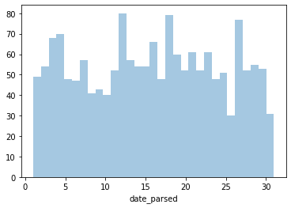

```python
# remove na's
day_of_month_landslides = day_of_month_landslides.dropna()

# plot the day of the month
sns.distplot(day_of_month_landslides, kde=False, bins=31)
```

## Dates and Times in Python

The Python world has a number of available representations of dates, times, deltas, and timespans. While the time series tools provided by Pandas tend to be the most useful for data science applications, it is helpful to see their relationship to other packages used in Python.

### Typed arrays of times: NumPy's `datetime64`

The weaknesses of Python's datetime format inspired the NumPy team to add a set of native time series data type to NumPy. The `datetime64` dtype encodes dates as 64-bit integers, and thus allows arrays of dates to be represented very compactly. The `datetime64` requires a very specific input format:

```python
import numpy as np
date = np.array('2015-07-04', dtype=np.datetime64)
date
```

```
array('2015-07-04', dtype='datetime64[D]')
```

Once we have this date formatted, however, we can quickly do vectorized operations on it:

```python
date + np.arange(12)
```

```
array(['2015-07-04', '2015-07-05', '2015-07-06', '2015-07-07',
       '2015-07-08', '2015-07-09', '2015-07-10', '2015-07-11',
       '2015-07-12', '2015-07-13', '2015-07-14', '2015-07-15'],
      dtype='datetime64[D]')
```

One detail of the `datetime64` and `timedelta64` objects is that they are built on a *fundamental time unit*. Because the `datetime64` object is limited to 64-bit precision, the range of encodable times is $2^{64}$ times this fundamental unit. In other words, `datetime64` imposes a trade-off between *time resolution* and *maximum time span*.

For example, if you want a time resolution of one nanosecond, you only have enough information to encode a range of $2^{64}$ nanoseconds, or just under 600 years. NumPy will infer the desired unit from the input; for example, here is a day-based datetime:

```python
np.datetime64('2015-07-04')
```

```
numpy.datetime64('2015-07-04')
```

Here is a minute-based datetime:

```python
np.datetime64('2015-07-04 12:00')
```

```
numpy.datetime64('2015-07-04T12:00')
```

Notice that the time zone is automatically set to the local time on the computer executing the code. You can force any desired fundamental unit using one of many format codes; for example, here we'll force a nanosecond-based time:

```python
np.datetime64('2015-07-04 12:59:59.50', 'ns')
```

```
numpy.datetime64('2015-07-04T12:59:59.500000000')
```

The following table, drawn from the [NumPy datetime64 documentation](http://docs.scipy.org/doc/numpy/reference/arrays.datetime.html), lists the available format codes along with the relative and absolute timespans that they can encode:

| Code | Meaning | Time span (relative) | Time span (absolute) |
| --- | --- | --- | --- |
| `Y` | Year | ± 9.2e18 years | [9.2e18 BC, 9.2e18 AD] |
| `M` | Month | ± 7.6e17 years | [7.6e17 BC, 7.6e17 AD] |
| `W` | Week | ± 1.7e17 years | [1.7e17 BC, 1.7e17 AD] |
| `D` | Day | ± 2.5e16 years | [2.5e16 BC, 2.5e16 AD] |
| `h` | Hour | ± 1.0e15 years | [1.0e15 BC, 1.0e15 AD] |
| `m` | Minute | ± 1.7e13 years | [1.7e13 BC, 1.7e13 AD] |
| `s` | Second | ± 2.9e12 years | [ 2.9e9 BC, 2.9e9 AD] |
| `ms` | Millisecond | ± 2.9e9 years | [ 2.9e6 BC, 2.9e6 AD] |
| `us` | Microsecond | ± 2.9e6 years | [290301 BC, 294241 AD] |
| `ns` | Nanosecond | ± 292 years | [ 1678 AD, 2262 AD] |
| `ps` | Picosecond | ± 106 days | [ 1969 AD, 1970 AD] |
| `fs` | Femtosecond | ± 2.6 hours | [ 1969 AD, 1970 AD] |
| `as` | Attosecond | ± 9.2 seconds | [ 1969 AD, 1970 AD] |

For the types of data we see in the real world, a useful default is `datetime64[ns]`, as it can encode a useful range of modern dates with a suitably fine precision.

Finally, we will note that while the `datetime64` data type addresses some of the deficiencies of the built-in Python `datetime` type, it lacks many of the convenient methods and functions provided by `datetime` and especially `dateutil`.

### Native Python dates and times: `datetime` and `dateutil`

Python's basic objects for working with dates and times reside in the built-in `datetime` module. Along with the third-party `dateutil` module, you can use it to quickly perform a host of useful functionalities on dates and times. For example, you can manually build a date using the `datetime` type:

```python
from datetime import datetime
datetime(year=2015, month=7, day=4)
```

```
datetime.datetime(2015, 7, 4, 0, 0)
```

Or, using the `dateutil` module, you can parse dates from a variety of string formats:

```python
from dateutil import parser
date = parser.parse("4th of July, 2015")
date
```

```
datetime.datetime(2015, 7, 4, 0, 0)
```

Once you have a `datetime` object, you can do things like printing the day of the week:

```python
date.strftime('%A')
```

```
'Saturday'
```

In the final line, we've used one of the standard string format codes for printing dates (`"%A"`), which you can read about in the [strftime section](https://docs.python.org/3/library/datetime.html#strftime-and-strptime-behavior) of Python's [datetime documentation](https://docs.python.org/3/library/datetime.html). Documentation of other useful date utilities can be found in [dateutil's online documentation](http://labix.org/python-dateutil). A related package to be aware of is [`pytz`](http://pytz.sourceforge.net/), which contains tools for working with the most migrane-inducing piece of time series data: time zones.

The power of `datetime` and `dateutil` lie in their flexibility and easy syntax: you can use these objects and their built-in methods to easily perform nearly any operation you might be interested in. Where they break down is when you wish to work with large arrays of dates and times: just as lists of Python numerical variables are suboptimal compared to NumPy-style typed numerical arrays, lists of Python datetime objects are suboptimal compared to typed arrays of encoded dates.

### Dates and times in pandas: best of both worlds

Pandas builds upon all the tools just discussed to provide a `Timestamp` object, which combines the ease-of-use of `datetime` and `dateutil` with the efficient storage and vectorized interface of `numpy.datetime64`. From a group of these `Timestamp` objects, Pandas can construct a `DatetimeIndex` that can be used to index data in a `Series` or `DataFrame`; we'll see many examples of this below.

For example, we can use Pandas tools to repeat the demonstration from above. We can parse a flexibly formatted string date, and use format codes to output the day of the week:

```python
import pandas as pd
date = pd.to_datetime("4th of July, 2015")
date
```

```
Timestamp('2015-07-04 00:00:00')
```

```python
date.strftime('%A')
```

```
'Saturday'
```

Additionally, we can do NumPy-style vectorized operations directly on this same object:

```python
date + pd.to_timedelta(np.arange(12), 'D')
```

```
DatetimeIndex(['2015-07-04', '2015-07-05', '2015-07-06', '2015-07-07',
               '2015-07-08', '2015-07-09', '2015-07-10', '2015-07-11',
               '2015-07-12', '2015-07-13', '2015-07-14', '2015-07-15'],
              dtype='datetime64[ns]', freq=None)
```

In the next section, we will take a closer look at manipulating time series data with the tools provided by Pandas.

## Pandas Time Series: Indexing by Time

Where the Pandas time series tools really become useful is when you begin to *index data by timestamps*. For example, we can construct a `Series` object that has time indexed data:

```python
index = pd.DatetimeIndex(['2014-07-04', '2014-08-04',
                          '2015-07-04', '2015-08-04'])
data = pd.Series([0, 1, 2, 3], index=index)
data
```

```
2014-07-04    0
2014-08-04    1
2015-07-04    2
2015-08-04    3
dtype: int64
```

Now that we have this data in a `Series`, we can make use of any of the `Series` indexing patterns we discussed in previous sections, passing values that can be coerced into dates:

```python
data['2014-07-04':'2015-07-04']
```

```
2014-07-04    0
2014-08-04    1
2015-07-04    2
dtype: int64
```

There are additional special date-only indexing operations, such as passing a year to obtain a slice of all data from that year:

```python
data['2015']
```

```
2015-07-04    2
2015-08-04    3
dtype: int64
```

Later, we will see additional examples of the convenience of dates-as-indices. But first, a closer look at the available time series data structures.

## Pandas Time Series Data Structures

This section will introduce the fundamental Pandas data structures for working with time series data:

- For *time stamps*, Pandas provides the `Timestamp` type. As mentioned before, it is essentially a replacement for Python's native `datetime`, but is based on the more efficient `numpy.datetime64` data type. The associated Index structure is `DatetimeIndex`.
- For *time Periods*, Pandas provides the `Period` type. This encodes a fixed-frequency interval based on `numpy.datetime64`. The associated index structure is `PeriodIndex`.
- For *time deltas* or *durations*, Pandas provides the `Timedelta` type. `Timedelta` is a more efficient replacement for Python's native `datetime.timedelta` type, and is based on `numpy.timedelta64`. The associated index structure is `TimedeltaIndex`.

The most fundamental of these date/time objects are the `Timestamp` and `DatetimeIndex` objects. While these class objects can be invoked directly, it is more common to use the `pd.to_datetime()` function, which can parse a wide variety of formats. Passing a single date to `pd.to_datetime()` yields a `Timestamp`; passing a series of dates by default yields a `DatetimeIndex`:

```python
dates = pd.to_datetime([datetime(2015, 7, 3), '4th of July, 2015',
                       '2015-Jul-6', '07-07-2015', '20150708'])
dates
```

```
DatetimeIndex(['2015-07-03', '2015-07-04', '2015-07-06', '2015-07-07',
               '2015-07-08'],
              dtype='datetime64[ns]', freq=None)
```

Any `DatetimeIndex` can be converted to a `PeriodIndex` with the `to_period()` function with the addition of a frequency code; here we'll use `'D'` to indicate daily frequency:

```python
dates.to_period('D')
```

```
PeriodIndex(['2015-07-03', '2015-07-04', '2015-07-06', '2015-07-07',
             '2015-07-08'],
            dtype='period[D]', freq='D')
```

A `TimedeltaIndex` is created, for example, when a date is subtracted from another:

```python
dates - dates[0]
```

```
TimedeltaIndex(['0 days', '1 days', '3 days', '4 days', '5 days'], dtype='timedelta64[ns]', freq=None)
```